# Using OpenStreetMap data in R

Brendan O’Dowd

2023-01-03

## Context

I once had to produce a map examining a land use transition from bogs for peat-cutting to areas for windfarms. I decided it would be useful to import outlines of bogs and locations of wind turbines from OpenStreetMaps.

## Setup

We need a couple of packages to start out with. Tidyverse is used for general data manipulation. The sf package is for managing and plotting maps (shapes, more generally) in R. It is installed with tidyverse but not loaded with it. The osmdata package allows us to import OpenStreetMap data into R as either ‘sf’ or ‘sp’ objects (prefer ‘sf’ objects). I also need a map of Irish counties. You can get such a map from several places; here I use my own map of 166 local electoral areas and convert that into a county map.

```r
library(tidyverse)
library(sf)
library(osmdata)
library(cowplot)
```

```r
county_map <- st_read("https://raw.githubusercontent.com/brendanjodowd/maps/main/lea_166.geojson") %>%
  group_by(COUNTY) %>%
  summarise(geometry = st_union(geometry) , AREA=sum(AREA))
```

## Importing data from OpenStreetMaps

### Query overview

We first create an ‘Overpass query’ for OpenStreetMaps using the function `opq`. This can take as its argument the name of a place, or a bounding box using latitude and longitude coordinates. See the help section on that function for further details.

Then the function `add_osm_feature` specifies the kinds of map objects that you want to return. It requires both a `key` and a `value` argument. The `key` argument is a feature key, sort of like a category of map object. Some of the options for `key` are ‘boundary’, ‘amenity’, and ‘natural’. The `value` argument is a specific class of object within that feature key. There is a very wide range of values available within the different keys, such as ‘forest’, ‘supermarket’, ‘cathedral’. Have a look [at this list of features](https://wiki.openstreetmap.org/wiki/Map_features) for a sense of what can be imported. I’m not sure if that list is exhaustive, or whether everything on it can be easily imported.

In the example for wind turbines, I use `key = "power"` and `value = "generator"`. Note that this imports lots of different devices that generate electricity, but I can filter to wind turbines later on.

At the point of the `add_osm_feature` function, all you have done is defined the query that you want to run, you haven’t actually imported any data yet. That is done by the function `osmdata_sf`, which gathers the data and outputs an sf object. This function can take a while to run, and may not always run successfully, so it may be best to save the resulting object to file at this point before you make further modifications.

The object returned by `osmdata_sf` is a list which includes a couple of named dataframes: osm_points, osm_lines, osm_polygons, osm_multilines, and osm_multipolygons. Depending on the objects you’re trying to import, they may be located in one or more of these dataframes. I think it is up to the OpenStreetMaps user who uploads the data in the first place to decide which geometry type is most appropriate.

```r
turbines_query <- opq("Ireland") %>%
  add_osm_feature(key = "power" , value = "generator") %>%
  osmdata_sf()
```

### Getting wind turbine locations

Having looked at the various dataframes mentioned above within the `turbines_query` list-object, I found that all of the wind turbines are in the osm_points dataframe. Here I create a copy of that osm_points dataframe called `turbines`. One of the columns is called `generator.method`, and I filter just the rows where that is equal to `"wind_turbine"`. There are a lot of other variables, so I choose just a few that are of interest to me using `select`. Note that the GEOMETRY column is kept by default and doesn’t have to be specified in `select` for sf objects.

```r
turbines <- turbines_query$osm_points

turbines <- turbines %>%
  filter(generator.method=="wind_turbine") %>%
  select(name, generator.output.electricity, manufacturer, operator)
```

Here is the `turbines` dataframe.

|  | name | generator.output.electricity | manufacturer | operator | geometry |
| --- | --- | --- | --- | --- | --- |
| 370577265 | Beallough Wind Farm | NA | NA | Tornado Electrical Ltd | POINT (-7.344967 52.2733) |
| 370577267 | Beallough Wind Farm | NA | NA | Tornado Electrical Ltd | POINT (-7.341947 52.27295) |
| 401877363 | NA | 0.25 MW | NA | Comharchumann Inis Meáin Teo | POINT (-9.600176 53.06939) |
| 401877364 | NA | 0.25 MW | NA | Comharchumann Inis Meáin Teo | POINT (-9.600366 53.06791) |
| 401877365 | NA | 0.25 MW | NA | Comharchumann Inis Meáin Teo | POINT (-9.599374 53.06847) |
| 410873377 | NA | 1.3 MW | Nordex | Greenoge Windfarm Ltd | POINT (-6.726101 52.6585) |
| 410873379 | NA | 1.3 MW | Nordex | Greenoge Windfarm Ltd | POINT (-6.728386 52.66074) |
| 410873382 | NA | 1.3 MW | Nordex | Greenoge Windfarm Ltd | POINT (-6.72302 52.65667) |
| 410873383 | NA | 1.3 MW | Nordex | Greenoge Windfarm Ltd | POINT (-6.72467 52.65481) |
| 432678296 | NA | 0.85 MW | Vestas | NA | POINT (-8.008761 52.82988) |
| 447399024 | NA | NA | NA | NA | POINT (-6.18387 54.73203) |
| 475386252 | NA | NA | NA | NA | POINT (-6.099892 54.80442) |
| 475386352 | NA | NA | NA | NA | POINT (-6.101351 54.80629) |
| 475386353 | NA | NA | NA | NA | POINT (-6.1053 54.80607) |
| 475386359 | NA | NA | NA | NA | POINT (-6.10742 54.8039) |
| 475386361 | NA | NA | NA | NA | POINT (-6.103669 54.8042) |
| 475386374 | NA | NA | NA | NA | POINT (-6.10572 54.80211) |
| 475386391 | NA | NA | NA | NA | POINT (-6.102055 54.80252) |
| 475386393 | NA | NA | NA | NA | POINT (-6.098407 54.80293) |
| 475386394 | NA | NA | NA | NA | POINT (-6.100854 54.80111) |
| 475386395 | NA | NA | NA | NA | POINT (-6.104433 54.80076) |
| 598162559 | NA | NA | NA | Dublin City Council | POINT (-6.160434 53.40567) |
| 839155529 | NA | NA | NA | NA | POINT (-6.024985 53.49471) |
| 885438777 | NA | 0.85 MW | Vestas | SWS Gneeves Wind Farm Limited | POINT (-9.119616 52.01623) |
| 885438788 | NA | 0.85 MW | Vestas | SWS Gneeves Wind Farm Limited | POINT (-9.117026 52.01467) |
| 885438789 | NA | 0.85 MW | Vestas | SWS Gneeves Wind Farm Limited | POINT (-9.113983 52.01346) |
| 904358706 | NA | 2 MW | Enercon | Ballywater Windfarms Ltd | POINT (-6.243706 52.53947) |
| 904358707 | NA | 2 MW | Enercon | Ballywater Windfarms Ltd | POINT (-6.246772 52.53791) |
| 904358708 | NA | 2 MW | Enercon | Ballywater Windfarms Ltd | POINT (-6.243069 52.53703) |
| 904358709 | NA | 2 MW | Enercon | Ballywater Windfarms Ltd | POINT (-6.235669 52.53898) |

[output cut: 3119 more lines]

Let’s see what we have.

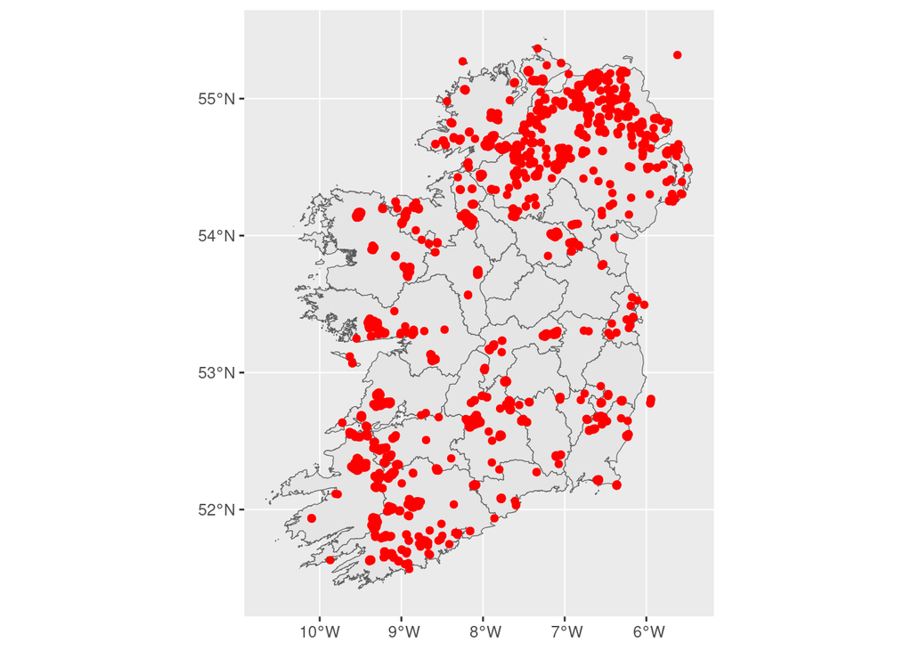

```r
ggplot(county_map) + geom_sf() +
  geom_sf(data = turbines , colour="red")
```

### Bogs

There isn’t a specific `key`/`value` feature for ‘bogs’ as we might understand them in Ireland, but I found that the `"wetland"` feature matched my requirements for this project.

```r
bogs_query <- opq("Ireland") %>%
  add_osm_feature(key = "natural" , value = "wetland") %>%
  osmdata_sf()
```

It turns out that some bogs/wetlands are uploaded as polygons and others are uploaded as multipolygons, and so they are contained within two different dataframes within the `bogs_query` list-object. I decide to combine them both using `bind_rows` to create a new dataframe called `bogs`. Then I select a few variables which are of interest.

```r
bogs <- bind_rows(bogs_query$osm_polygons  ,
                 bogs_query$osm_multipolygons) %>%
  select( name , wetland)
```

Here is the first 100 rows from the `bogs` dataframe (without the GEOMETRY column).

|  | name | wetland |
| --- | --- | --- |
| 4555034 | NA | tidalflat |
| 4555102 | NA | tidalflat |
| 4556142 | NA | NA |
| 4561722 | NA | NA |
| 5404872 | NA | tidalflat |
| 6957911 | Corraback Lough | NA |
| 23615523 | Bun Lough | NA |
| 23615524 | Putiaghan Lough | NA |
| 23615526 | Commons Lough | NA |
| 23615527 | Tonawolly Lough | NA |
| 23615572 | Shancorry Lough | NA |
| 23615595 | Faharlagh Lough | NA |
| 23615596 | Edenterriff Lough | NA |
| 23615600 | Derreary Lough | NA |
| 23615719 | Lough Amoneen | NA |
| 23618883 | NA | NA |
| 23619293 | Swan Lough | NA |
| 23619294 | Peartree Lough | NA |
| 23619342 | Coalpit Lough | NA |
| 23619485 | Corfad Lough | NA |
| 23740903 | Doogan Lough | NA |
| 23858970 | NA | wet_meadow |
| 25569869 | NA | NA |
| 31025273 | NA | NA |
| 31025469 | Dernaweel Lough | NA |
| 31119401 | Cortial Lough | NA |
| 31119986 | NA | NA |
| 31120056 | NA | NA |
| 31120058 | NA | NA |
| 31558458 | Ardakillin Lough | NA |

[output cut: 70 more lines]

Let’s have a look at what we’ve got.

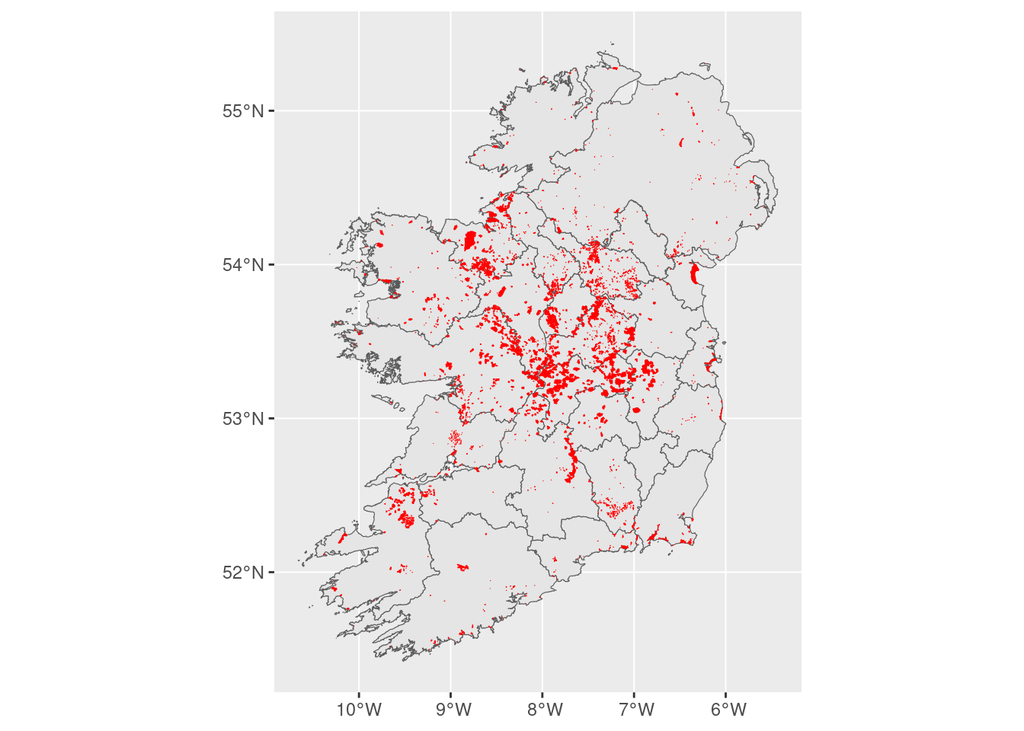

```r
ggplot(county_map) + geom_sf() +
  geom_sf(data = bogs , fill="red" , colour = "red")
```

### Some extra turbines.

There’s actually a new windfarm in a part of Tipperary that I wanted to include. I found these coordinates manually from Google Maps, and they can be turned into an sf object as shown below. Their coordinate reference system (CRS) is set to be the same as that for `county_map` (WGS 84).

```r
new_turbines <- tribble(
  ~lat , ~long,
  52.61594839110318, -7.69242746150073,
  52.61276941295214, -7.686762636061125,
  52.60836536508515, -7.682256524916086,
  52.636185727368925, -7.660562886949663,
  52.64386809365363, -7.651893987413578,
  52.64449732500331, -7.66927492954084,
  52.65019471092566, -7.659118918231185,
  52.65509578182991, -7.661757585929191,
  52.65509578182991, -7.64464259368543,
  52.65822504258744, -7.651925569108475,
  52.664671978288375, -7.655918392931982,
  52.665973321164486, -7.641241345202222,
  52.671348708560096, -7.649956877758161,
  52.67446892090545, -7.657981275577273
  ) %>%
  st_as_sf(coords = c("long", "lat"), crs = st_crs(county_map))
```

## Plotting

Ok, let’s map all of this for a section of Tipperary. I’m cropping to this part of the country using `xlim` and `ylim`. Turbines are plotted as open circles using `shape=1` (there are a couple of places online where you can check out all the different point shapes available, [here](https://www.datanovia.com/en/blog/ggplot-point-shapes-best-tips/) is one website that has them). Axes and other unwanted plot items are removed using `theme_void`. The background is set to a dark grey colour using the `plot.background` argument within a `theme` function.

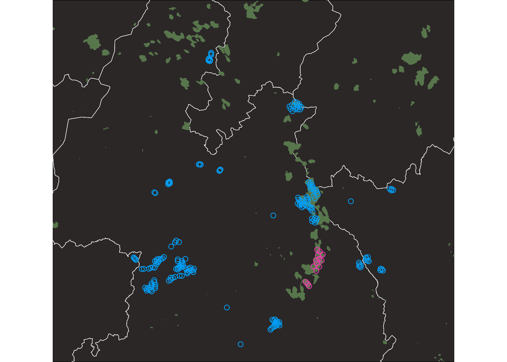

```r
ggplot(county_map)+
  geom_sf(size=1.5, fill=NA , colour = "white") +
  geom_sf(data=bogs, fill="#58764C", colour="#58764C", size=1) +
  geom_sf(data=turbines, colour = "#00A2FF", shape=1, size=2 ) +
  geom_sf(data=new_turbines, colour = "#FB37B4" , shape=1, size=2 ) +
  xlim(-8.4,-7.3) + ylim(52.5, 53.1) +
  theme_void() +
  theme(plot.background = element_rect(fill = "#2B2727"))
```